# jpmesh: 標準地域メッシュを扱うためのライブラリ

jpmeshパッケージは、日本国内で利用される「地域メッシュ（メッシュコード）」をRから容易に利用可能にするパッケージです。地域メッシュとは、日本国土を緯度・経度により方形の小地域区画に細分することで、同一の基準による統計調査などの結果を得ることが可能となります。80kmから125mまでのメッシュコードに対応し、メッシュコードと緯度経度座標との相互変換を行います。

jpmeshの主な機能として、「緯度経度からの地域メッシュへの変換」、「地域メッシュからの緯度経度の取得」、「都道府県単位やleaflet上へのマッピング」があります。なお地域メッシュと緯度経度の変換の基礎は竹中明夫さんのRコードが基礎となっています。ここではその使い方を紹介します。

パッケージをインストールしたら環境内で利用可能にするため、読み込みを行いましょう。また、このサンプルページで用いるパッケージも同時に読み込むようにしておきます。

```r
library(jpmesh)
library(dplyr)
library(purrr)
library(sf)

library(ggplot2)
library(leaflet)
```

`mesh_to_coords()`を利用し、メッシュコードが位置する座標を取得します。この時、メッシュの重心が緯度経度として使われます。メッシュの4から11桁、すなわち第1次地域区画(80kmメッシュ)から8分の1地域メッシュ(125mメッシュ)にまで対応します。

```r
mesh_to_coords(5133) # 80km mesh
```

| lng_center | lat_center | lng_error | lat_error |
| --- | --- | --- | --- |
| 133.5 | 34.33333 | 0.5 | 0.3333333 |

```r
mesh_to_coords(51337783123) # 125m mesh
```

| lng_center | lat_center | lng_error | lat_error |
| --- | --- | --- | --- |
| 133.9164 | 34.65156 | 0.00078125 | 0.0005208333 |

座標からメッシュコードを取得することも可能です。`coords_to_mesh()`の引数*longitude*および*latitude*に経度と緯度をそれぞれ与えます。この時、メッシュの大きさを*mesh_size*で指定します。

```r
coords_to_mesh(longitude = 133,
               latitude = 34,
               mesh_size = "80km")
```

```
[1] "5133"
```

```r
coords_to_mesh(longitude = 133,
               latitude = 34,
               mesh_size = "1km")
```

```
[1] "51330000"
```

また対象の地域メッシュ内に含まれる緯度経度からスケールダウンした地域メッシュや、隣接するメッシュコードを得ることができます。

```r
# 1km メッシュに含まれる500mメッシュコードを取得します
coords_to_mesh(133, 34, "1km") %>%
  fine_separate()
```

```
[1] "513300001" "513300002" "513300003" "513300004"
```

```r
# 隣接するメッシュコードを返す
mesh_neighborhood <- coords_to_mesh(133, 34, "80km") %>%
  neighbor_mesh()
mesh_neighborhood
```

```
[1] "5032" "5033" "5034" "5132" "5133" "5134" "5232" "5233" "5234"
```

```r
df_polys <- mesh_neighborhood %>%
  export_meshes()
```

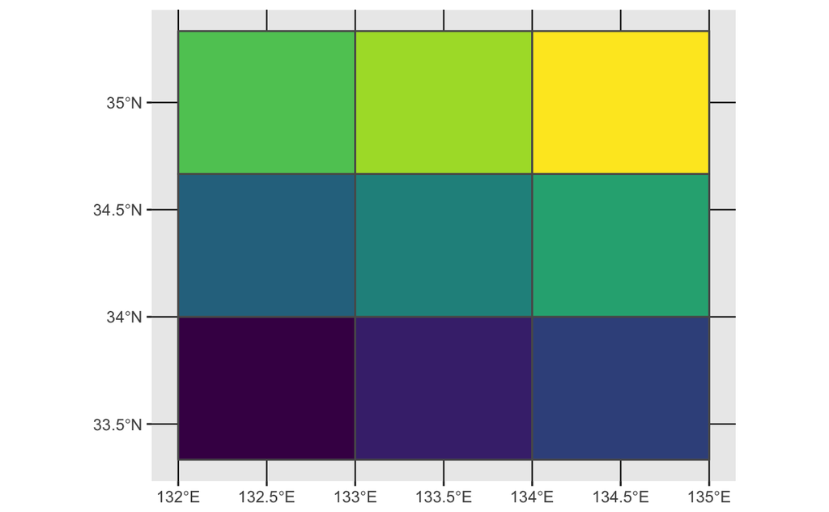

```r
ggplot() +
  geom_sf(data = df_polys, fill = viridis::viridis(9))
```

```
Ignoring unknown parameters: min.segment.length
```

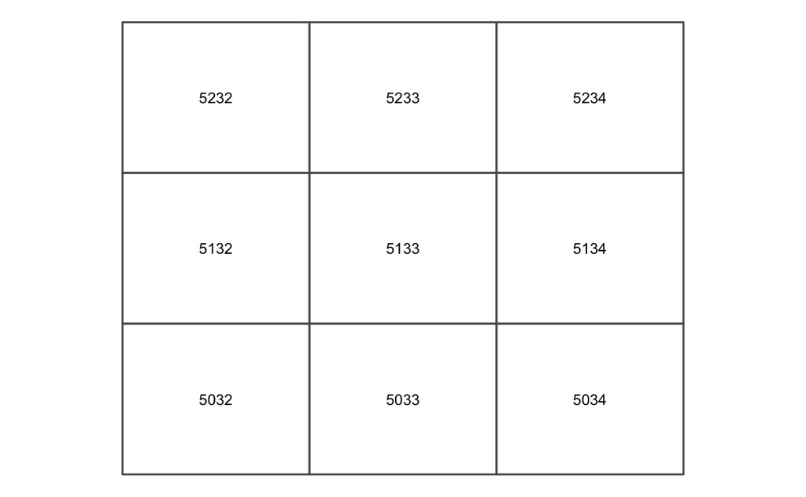

```r
ggplot() +
  geom_sf(data = df_polys, fill = NA) +
  geom_text(data = df_polys %>% dplyr::mutate(
    CENTROID = map(geometry, st_centroid),
    COORDS = map(CENTROID, st_coordinates),
    COORDS_X = map_dbl(COORDS, 1),
    COORDS_Y = map_dbl(COORDS, 2)
  ),
    aes(COORDS_X, COORDS_Y, label = meshcode),
    size = 3, min.segment.length = 0) +
  coord_sf(datum = NA) +
  theme_void()
```

```r
leaflet() %>%
  addTiles() %>%
  addPolygons(data = df_polys,
              fillOpacity = 0.2) %>%
  addCircleMarkers(
    data         = suppressWarnings(df_polys %>% sf::st_centroid()),
    radius       = NULL,
    fillOpacity  = 0.1,
    label        = ~meshcode,
    labelOptions = labelOptions(
      direction = "bottom",
      noHide    = TRUE,
      textOnly  = TRUE,
      style = list(
        "color"      = viridis::viridis(10)[10],
        "font-style" = "italic",
        "font-size"  = "22px")))
```

[interactive chart not shown]